# Correlation

#### I wish to see what is the correlation between the S&P 500, Hang Seng index and the a few companies that will be used to represent (precious) metal stocks.

The aim of this is to skimly assess the reduction of risk with investing in these indices.

```python
import pickle
import pandas as pd
%matplotlib inline
import random
import matplotlib.pyplot as plt
import numpy as np
import seaborn as sns
import datetime as dt
import pandas_datareader.data as web
import requests
import os
import bs4 as bs
```

Pull data from Yahoo Finance through the 'pandas_datareader' module

```python
start = dt.datetime(1970, 1, 1)
end = dt.datetime.now()
```

```python
SP_500_df = web.DataReader('^GSPC', 'yahoo', start, end)

Hang_seng_df = web.DataReader('^HSI', 'yahoo', start, end)
```

Using beautiful soup to read and copy ticker names from a certain column of a table.

```python
resp = requests.get('https://topforeignstocks.com/stock-lists/the-complete-list-of-precious-metals-stocks-trading-on-the-nyse/')
soup = bs.BeautifulSoup(resp.text, 'lxml')
table = soup.find('table', {'class': 'tablepress'})
tickers_metal = []
for row in table.findAll('tr')[1:]:
    ticker = row.findAll('td')[2].text
    totickers_metal.append(ticker)

#Clean the tickers
tickers_metal = [s.replace ('\n', '') for s in tickers_metal]
```

```python
# If one wishes to have the names of the companies

metal_companies = []
for row in table.findAll('tr')[1:]:
    ticker = row.findAll('td')[1].text
    metal_companies.append(ticker)

metal_companies =[s.replace ('\n', '') for s in metal_companies]
```

Use the tickers names from a list to pull data into a DataFrame.

```python
# metal companies' ticker

for ticker in tickers_metal:
    if not os.path.exists('metal_ticks/{}.pkl'.format(ticker)):
        try:
            df = web.DataReader(ticker, 'yahoo', start, end)
        except:
            pass
        df.reset_index(inplace=True)
        df.set_index("Date", inplace=True)
        #df = df.drop("Symbol", axis=1)
        df.to_pickle('metal_ticks/{}.pkl'.format(ticker))
    else:
        print('Already have {}'.format(ticker))
```

Append all the metal companies to a single dataframe

```python
metal_df = pd.DataFrame()

for count, ticker in enumerate(tickers_metal):
    df = pd.read_pickle('metal_ticks/{}.pkl'.format(ticker))
    df.rename(columns={'Adj Close': ticker}, inplace=True)
    df.drop(['Open', 'High', 'Low', 'Close', 'Volume'], 1, inplace=True)

    if metal_df.empty:
        metal_df = df
    else:
        metal_df = metal_df.join(df, how='outer')
```

```python
metal_df.head()
```

| Date | AEM | AGI | AU | ABX | BHP | CCJ | CLF | CDE | DRD | EGO | ... | PVG | RIO | SA | SBGL | SCCO | TAHO | TRQ | WPM | AUY | VALE |
| --- | --- | --- | --- | --- | --- | --- | --- | --- | --- | --- | --- | --- | --- | --- | --- | --- | --- | --- | --- | --- | --- |
| 1980-03-17 | 6.242503 | NaN | NaN | NaN | 0.039225 | NaN | -0.004893 | 133.777298 | NaN | NaN | ... | NaN | NaN | NaN | NaN | NaN | NaN | NaN | NaN | NaN | NaN |
| 1980-03-18 | 5.989430 | NaN | NaN | NaN | 0.039613 | NaN | -0.004688 | 137.711914 | NaN | NaN | ... | NaN | NaN | NaN | NaN | NaN | NaN | NaN | NaN | NaN | NaN |
| 1980-03-19 | 7.254803 | NaN | NaN | NaN | 0.041943 | NaN | -0.004729 | 149.515762 | NaN | NaN | ... | NaN | NaN | NaN | NaN | NaN | NaN | NaN | NaN | NaN | NaN |
| 1980-03-20 | 7.170444 | NaN | NaN | NaN | 0.041555 | NaN | -0.004729 | 153.450409 | NaN | NaN | ... | NaN | NaN | NaN | NaN | NaN | NaN | NaN | NaN | NaN | NaN |
| 1980-03-21 | 7.170444 | NaN | NaN | NaN | 0.040001 | NaN | -0.004729 | 153.450409 | NaN | NaN | ... | NaN | NaN | NaN | NaN | NaN | NaN | NaN | NaN | NaN | NaN |

5 rows × 36 columns

Save the information into a pickle file to load later

```python
with open("metal_df.pkl", "wb") as f:
    pickle.dump(metal_df, f)

with open('metal_df.pkl','rb') as f:
    metal_df = pickle.load(f)
```

Average the values into monthly values

```python
metal_df.index = pd.to_datetime(metal_df.index)
metal_monthly = metal_df.resample("M").mean()
metal_monthly['mean'] = metal_monthly.mean(axis=1)
metal_mean = metal_monthly['mean']
```

```python
SP_500_df = SP_500_df['Adj Close']
SP_500_df_monthly = SP_500_df.resample("M").mean()

Hang_seng_df = Hang_seng_df['Adj Close']
Hang_seng_monthly = Hang_seng_df.resample("M").mean()
```

```python
SP_500_df_monthly.head()
```

```
Date
1969-12-31    92.059998
1970-01-31    90.332857
1970-02-28    87.164211
1970-03-31    88.652381
1970-04-30    85.952272
Freq: M, Name: Adj Close, dtype: float64
```

Put the separate DataFrames objects into a single DataFrame

```python
tri_df = pd.DataFrame()
tri_df['SP500'] = SP_500_df_monthly
tri_df['Hang Seng'] = Hang_seng_monthly
tri_df['metal'] = metal_mean
```

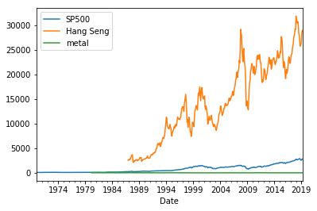

```python
tri_df.plot()
```

```python
# Set the starting date to 1987,as Hang Seng Index data set starts at this date.

tri_df = tri_df[(tri_df.index > '1987-01-31')]
```

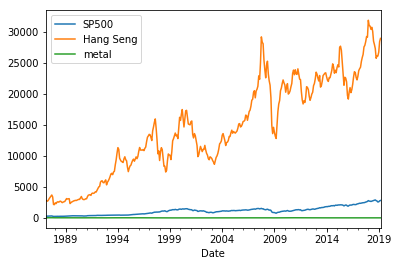

```python
tri_df.plot()
```

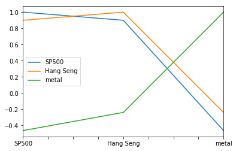

```python
tri_df_corr = tri_df.corr()
tri_df_corr.plot()
```

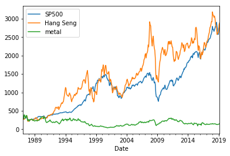

```python
tri_df_adj = tri_df

tri_df_adj['Hang Seng'] = tri_df['Hang Seng'] / 10
tri_df_adj['metal'] = tri_df['metal'] * 10


tri_df_adj.plot()
```

View the percentage change of the graph

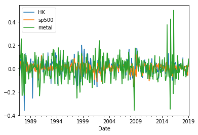

```python
pct_change_hk = Hang_seng_monthly.pct_change(periods =1)
pct_change_sp = SP_500_df_monthly.pct_change(periods =1)
pct_change_metal = metal_mean.pct_change(periods =1)

tri_df_pct = pd.DataFrame()
tri_df_pct['HK'] = pct_change_hk
tri_df_pct['sp500'] = pct_change_sp
tri_df_pct['metal'] = pct_change_metal

tri_df_pct.plot()
```

The corr_graph function allows the correlations to be viewed in a coloured grid

```python
def corr_graph(data):
    data1 = data.values
    fig1 = plt.figure()
    ax1 = fig1.add_subplot(111)

    heatmap1 = ax1.pcolor(data1, cmap=plt.cm.RdYlGn)
    fig1.colorbar(heatmap1)

    ax1.set_xticks(np.arange(data1.shape[1]) + 0.5, minor=False)
    ax1.set_yticks(np.arange(data1.shape[0]) + 0.5, minor=False)
    ax1.invert_yaxis()
    ax1.xaxis.tick_top()
    column_labels = data.columns
    row_labels = data.index
    ax1.set_xticklabels(column_labels)
    ax1.set_yticklabels(row_labels)
    plt.xticks(rotation=90)
    heatmap1.set_clim(-1, 1)
    plt.tight_layout()
    plt.show()
```

```python
tri_df_pct_corr
```

|  | HK | sp500 | metal |
| --- | --- | --- | --- |
| HK | 1.000000 | 0.612432 | 0.298861 |
| sp500 | 0.612432 | 1.000000 | 0.174422 |
| metal | 0.298861 | 0.174422 | 1.000000 |

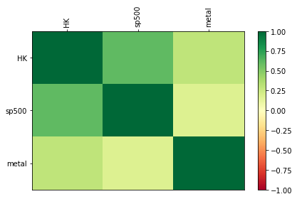

```python
corr_graph(tri_df_pct_corr)
```

```python
tri_df_adj_corr =tri_df_adj.corr()
```

```python
(tri_df_adj_corr)
```

|  | SP500 | Hang Seng | metal |
| --- | --- | --- | --- |
| SP500 | 1.000000 | 0.899427 | -0.463173 |
| Hang Seng | 0.899427 | 1.000000 | -0.238850 |
| metal | -0.463173 | -0.238850 | 1.000000 |

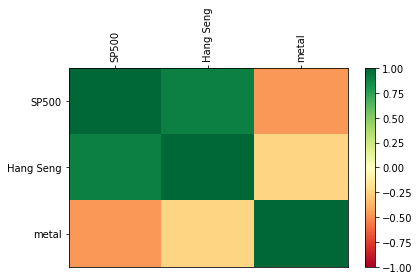

```python
corr_graph(tri_df_adj_corr)
```

### Evaluating the difference

It appears that in the long run there is a negative correlation with the metal companies as decrease over time in value.

Yet, there is a positive correlation with the monthly percentage change.

## Comparing the booms and the busts

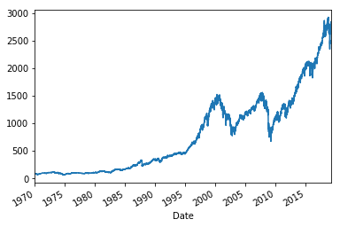

```python
SP_500_df.plot()
```

```python
tri_df_crash = tri_df_adj[(tri_df_adj.index > '1997-1-1') & (tri_df_adj.index <= '1999-01-01')]
tri_df_2007_boom = tri_df_adj[(tri_df_adj.index > '2005-1-1') & (tri_df_adj.index <= '2008-01-01')]
tri_df_present_boom = tri_df_adj[(tri_df_adj.index > '2015-1-1') & (tri_df_adj.index <= '2019-03-31')]
tri_df_2008_crash = tri_df_adj[(tri_df_adj.index > '2008-1-1') & (tri_df_adj.index <= '2011-01-01')]
```

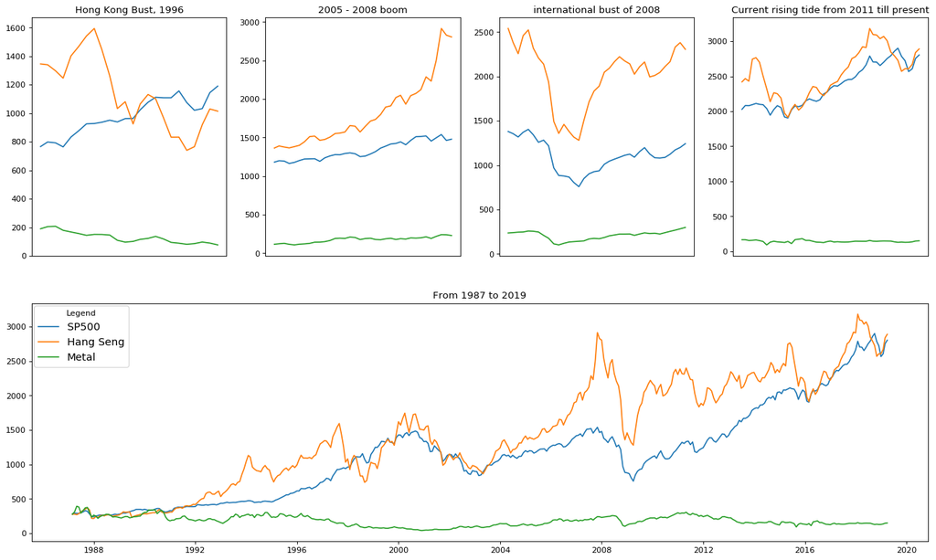

```python
fig=plt.figure(figsize=(20, 12), dpi= 80, facecolor='w', edgecolor='k')

from pylab import *

from matplotlib.gridspec import GridSpec


gs=GridSpec(2,4)

subplot(gs[0,0])
title('Hong Kong Bust, 1996')
plot(tri_df_crash)
plt.tick_params(
    axis='x',
    which='both',
    bottom=False,
    top=False,
    labelbottom=False)



subplot(gs[0,1])
title('2005 - 2008 boom')
plot(tri_df_2007_boom)
plt.tick_params(
    axis='x',
    which='both',
    bottom=False,
    top=False,
    labelbottom=False)



subplot(gs[0,2])
title('international bust of 2008')
plot(tri_df_2008_crash)
plt.tick_params(
    axis='x',
    which='both',
    bottom=False,
    top=False,
    labelbottom=False)



subplot(gs[0,3])
title('Current rising tide from 2011 till present')
plot(tri_df_present_boom)
plt.tick_params(
    axis='x',
    which='both',
    bottom=False,
    top=False,
    labelbottom=False)



subplot(gs[1,:])
title('From 1987 to 2019')
plot(tri_df_adj)
plt.legend(     # The line objects
           labels=['SP500', 'Hang Seng', 'Metal'],
           loc="upper left",
           borderaxespad=0.2,
           title="Legend",
           prop={'size': 13})


show()
```

```python
tri_df_crash_corr = tri_df_crash.corr()
tri_df_2007_boom_corr = tri_df_2007_boom.corr()
tri_df_present_boom_corr = tri_df_present_boom.corr()
tri_df_2008_crash_corr = tri_df_2008_crash.corr()
```

```
Correlation between 1987 to 2019
              SP500  Hang Seng     metal
SP500      1.000000   0.899427 -0.463173
Hang Seng  0.899427   1.000000 -0.238850
metal     -0.463173  -0.238850  1.000000
```

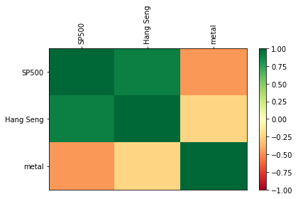

```
Correlation between 1997 to 1999
              SP500  Hang Seng     metal
SP500      1.000000  -0.666456 -0.852935
Hang Seng -0.666456   1.000000  0.774370
metal     -0.852935   0.774370  1.000000
```

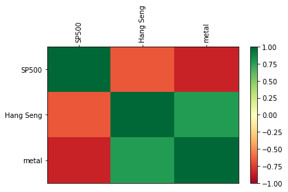

```
Correlation between 2005 to 2008
              SP500  Hang Seng     metal
SP500      1.000000   0.901073  0.815683
Hang Seng  0.901073   1.000000  0.811106
metal      0.815683   0.811106  1.000000
```

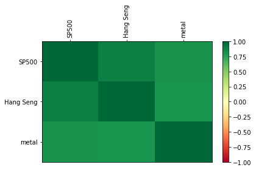

```
Correlation between 2008 to 2011
              SP500  Hang Seng     metal
SP500      1.000000   0.905005  0.801876
Hang Seng  0.905005   1.000000  0.911955
metal      0.801876   0.911955  1.000000
```

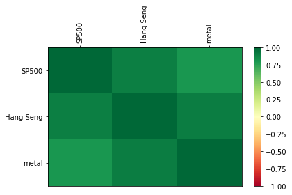

```
Correlation between 2015 to 2019
              SP500  Hang Seng     metal
SP500      1.000000   0.813073 -0.079567
Hang Seng  0.813073   1.000000  0.094718
metal     -0.079567   0.094718  1.000000
```

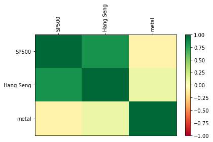

```python
gs=GridSpec(1,5)

print('Correlation between 1987 to 2019')
print(tri_df_adj_corr)
corr_graph(tri_df_adj_corr)

print('Correlation between 1997 to 1999')
print(tri_df_crash_corr)
corr_graph(tri_df_crash_corr)

print('Correlation between 2005 to 2008')
print(tri_df_2007_boom_corr)
corr_graph(tri_df_2007_boom_corr)

print('Correlation between 2008 to 2011')
print(tri_df_2008_crash_corr)
corr_graph(tri_df_2008_crash_corr)

print('Correlation between 2015 to 2019')
print(tri_df_present_boom_corr)
corr_graph(tri_df_present_boom_corr)
```

It seems that the value of metal as an investment is a bad investment with this ~ 30 year span data.

As for the correlation of SP500 and the Hang Seng are both highly correlated bar the localised Hong Kong crash of 1997.